# PS5: Markdown, basic plots

Christian Baldoza

2023-02-14

## 1.) Load and Check Data

```
## [1] "/Users/christianbaldoza/Documents/INFO201W23/ps5-markdown-christiannbal"
```

```
## # A tibble: 6 × 25
##   iso3  name  iso2  region sub-r…¹ inter…²  time total…³ ferti…⁴ lifeE…⁵ child…⁶
##   <chr> <chr> <chr> <chr>  <chr>   <chr>   <dbl>   <dbl>   <dbl>   <dbl>   <dbl>
## 1 ABW   Aruba AW    Ameri… Latin … Caribb…  1960   54211    4.82    65.7      NA
## 2 ABW   Aruba AW    Ameri… Latin … Caribb…  1961   55438    4.66    66.1      NA
## 3 ABW   Aruba AW    Ameri… Latin … Caribb…  1962   56225    4.47    66.4      NA
## 4 ABW   Aruba AW    Ameri… Latin … Caribb…  1963   56695    4.27    66.8      NA
## 5 ABW   Aruba AW    Ameri… Latin … Caribb…  1964   57032    4.06    67.1      NA
## 6 ABW   Aruba AW    Ameri… Latin … Caribb…  1965   57360    3.84    67.4      NA
## # … with 14 more variables: youthFemaleLiteracy <dbl>, youthMaleLiteracy <dbl>,
## #   adultLiteracy <dbl>, GDP_PC <dbl>, accessElectricity <dbl>,
## #   agriculturalLand <dbl>, agricultureTractors <dbl>, cerealProduction <dbl>,
## #   fertilizerHa <dbl>, co2 <dbl>, greenhouseGases <dbl>, co2_PC <dbl>,
## #   pm2.5_35 <dbl>, battleDeaths <dbl>, and abbreviated variable names
## #   ¹`sub-region`, ²`intermediate-region`, ³totalPopulation, ⁴fertilityRate,
## #   ⁵lifeExpectancy, ⁶childMortality
```

The *gapminder* has 13055 rows and 25 columns.

## 2.) Descriptive Statistics

1.) How many countries are there in the dataset? Analyze all three: iso3, iso2 and name.

2a.) find how many names are there for each iso-2 code. Are there any iso-2 codes that correspond to more than one name? What are these countries?

```
## # A tibble: 248 × 2
##    iso2  n_unique_region
##    <chr>           <int>
##  1 AD                  1
##  2 AE                  1
##  3 AF                  1
##  4 AG                  1
##  5 AI                  1
##  6 AL                  1
##  7 AM                  1
##  8 AO                  1
##  9 AQ                  1
## 10 AR                  1
## # … with 238 more rows
```

```
## # A tibble: 0 × 2
## # … with 2 variables: iso2 <chr>, region <chr>
```

Here we can see that there are no iso2 codes with multiple names.

2b.) Now repeat the same for name and iso3-code. Are there country names that have more than one iso3-code? What are these countries?

```
## # A tibble: 253 × 2
##    iso3  n_unique_region
##    <chr>           <int>
##  1 ABW                 1
##  2 AFG                 1
##  3 AGO                 1
##  4 AIA                 1
##  5 ALA                 1
##  6 ALB                 1
##  7 AND                 1
##  8 ARE                 1
##  9 ARG                 1
## 10 ARM                 1
## # … with 243 more rows
```

```
## # A tibble: 0 × 2
## # … with 2 variables: iso3 <chr>, region <chr>
```

```
## # A tibble: 249 × 2
##    name                n_unique_region
##    <chr>                         <int>
##  1 Afghanistan                       1
##  2 Albania                           1
##  3 Algeria                           1
##  4 American Samoa                    1
##  5 Andorra                           1
##  6 Angola                            1
##  7 Anguilla                          1
##  8 Antarctica                        1
##  9 Antigua and Barbuda               1
## 10 Argentina                         1
## # … with 239 more rows
```

```
## # A tibble: 0 × 2
## # … with 2 variables: name <chr>, region <chr>
```

Here we can see that there are no iso3, or name codes that have multiple names.

3.) What is the minimum and maximum year in these data?

The minimum year in the data would be 1960, and the maximum year in the data would be 2019.

## 3.) CO2 emissions

1.) How many missing co2 emissions are there for each year? Analyze both missing CO2 and co2_PC. Which years have most missing data?

```
## Years with the most missing CO2 values:
```

```
## 2017, 2018, 2019, 1960, 1961, 1962
```

```
## Years with the most missing CO2_PC values:
```

```
## 2017, 2018, 2019, 1960, 1961, 1962
```

2.) Make a plot of total CO2 emissions over time for the U.S, China, and India. Add a few more countries of your choice. Explain what do you see.

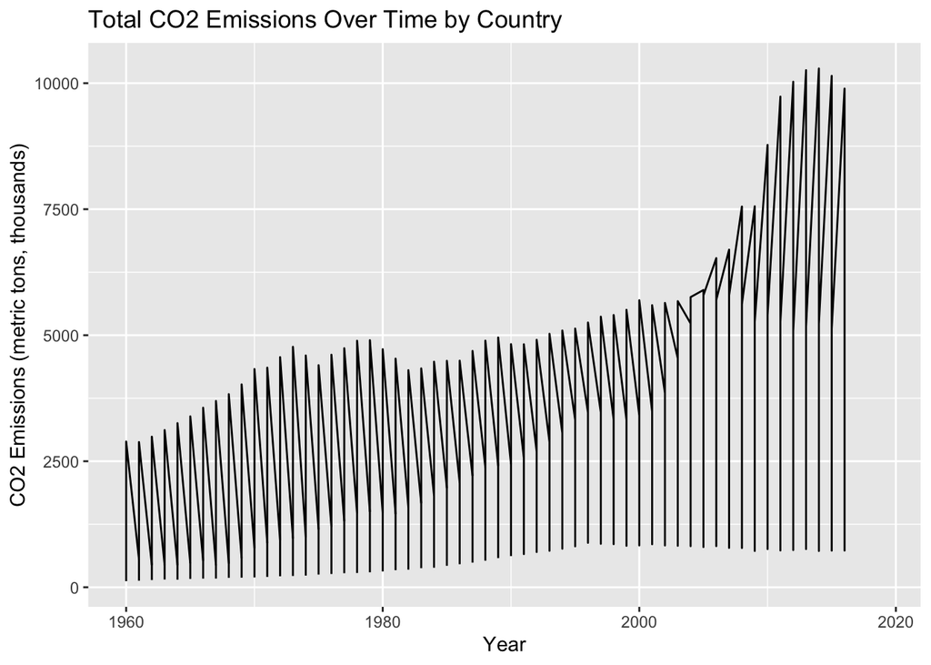

```r
library(ggplot2)
co2_data <- gapminder %>% filter(iso3 %in% c("USA", "CHN", "IND", "RUS", "DEU"))

ggplot(co2_data, aes(x = time, y = co2/1000)) +
  geom_line() +
  labs(title = "Total CO2 Emissions Over Time by Country", x = "Year", y = "CO2 Emissions (metric tons, thousands)")
```

```r
cat("\n")
```

3.) Now let’s analyze the CO2 emissions per capita (co2_PC ). Make a similar plot of the same countries. What does this figure suggest?

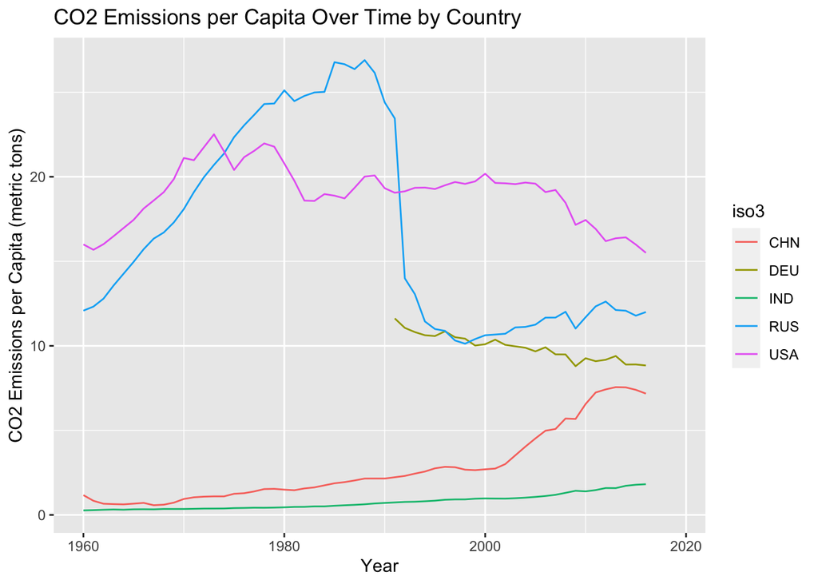

```r
gapminder$co2_PC <- as.numeric(as.character(gapminder$co2_PC))

co2_pc_data <- gapminder %>% filter(iso3 %in% c("USA", "CHN", "IND", "RUS", "DEU"))

ggplot(co2_pc_data, aes(x = time, y = co2_PC, color = iso3)) +
  geom_line() +
  labs(title = "CO2 Emissions per Capita Over Time by Country", x = "Year", y = "CO2 Emissions per Capita (metric tons)")
```

```r
cat("\n")
```

4.) Compute average CO2 emissions per capita across the continents (assume region is the same as continent). Comment what do you see.

```
## # A tibble: 6 × 2
##   region   mean_co2_pc
##   <chr>          <dbl>
## 1 Africa         0.930
## 2 Americas       6.46
## 3 Asia           6.21
## 4 Europe         7.95
## 5 Oceania        4.39
## 6 <NA>          16.2
```

From this average capita, we can generally see that out of all the continents, on average **Europe** had the *highest* amount of generated CO2 emissions per capita, pushing an average of 7.95 CO2 metric tons. The *lowest* generation of CO2 levels would be coming from the continent of **Africa**, only pushing out an average of 0.930 CO2 emissions.

5.) Make a barplot where you show the previous results–average CO2 emissions per capita across continents in 1960 and 2016.

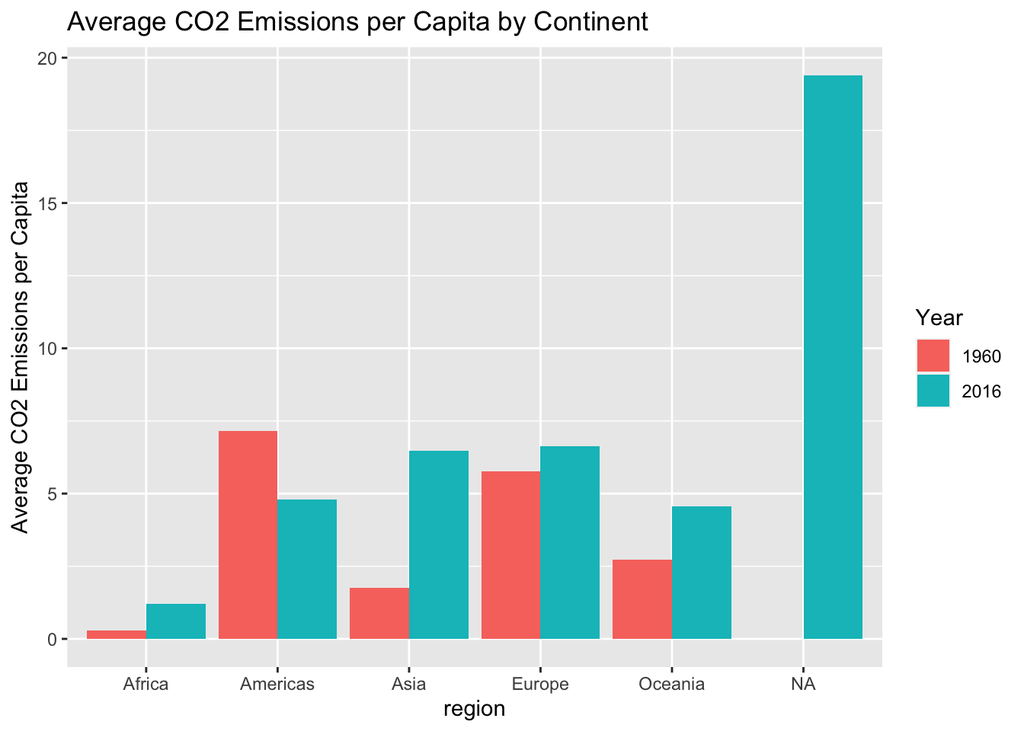

6.) Which countries are the three largest, and three smallest CO2 emitters (in terms of CO2 per capita) in 2019 for each continent?

```
## # A tibble: 6 × 4
## # Groups:   region [2]
##   name                     region    time co2_PC
##   <chr>                    <chr>    <dbl>  <dbl>
## 1 South Africa             Africa    2016   8.48
## 2 Libya                    Africa    2016   7.79
## 3 Seychelles               Africa    2016   6.39
## 4 Trinidad and Tobago      Americas  2016  31.8
## 5 United States of America Americas  2016  15.5
## 6 Canada                   Americas  2016  15.1
```

```
## # A tibble: 6 × 4
## # Groups:   region [2]
##   name            region   time co2_PC
##   <chr>           <chr>   <dbl>  <dbl>
## 1 Solomon Islands Oceania  2016  0.272
## 2 Vanuatu         Oceania  2016  0.527
## 3 Kiribati        Oceania  2016  0.587
## 4 <NA>            <NA>     2016  5.03
## 5 <NA>            <NA>     2016 33.8
## 6 <NA>            <NA>     2016 NA
```

As for the 3 smallest CO2 producing countries in the year 2016 (also not 2019, due to the data being missing) we see in ranking order: Soloman Islands, Vanuatu, and Kiribati, all located in the Oceania region.

## 4.) GDP per capita

1.) Let’s look at GDP per capita (GDP_PC ). Make a scatterplot of GDP per capita versus life expectancy by country, using data for 1960. Make the point size dependent on the country size, and color those according to the continent. Feel free to adjust the plot in other ways to make it better.

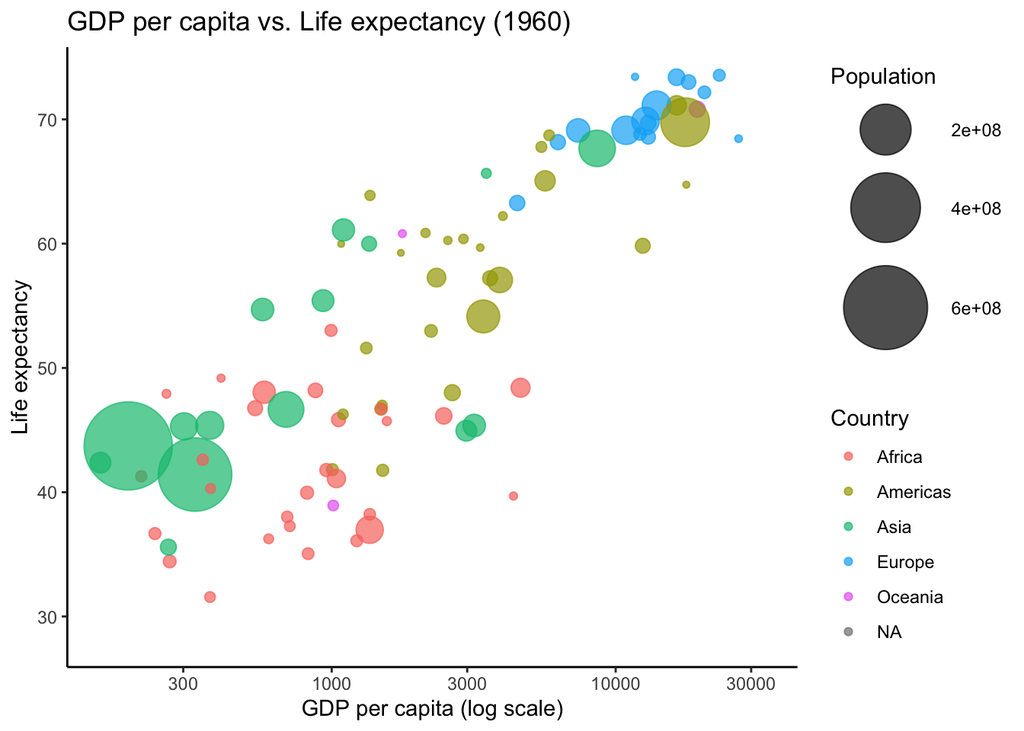

In this plot, we notice that on average, when evaluating GDP per capita vs Life expectancy in 1960, Europe and America ranked the highest in averages. On the otherhand, we see countries such as Asia and Africa ranking lowest in the scatterplot. However, the country with the highest average of appearance in the scatterplot, would be America.

2.) Make a similar plot, but this time use 2019 data only.

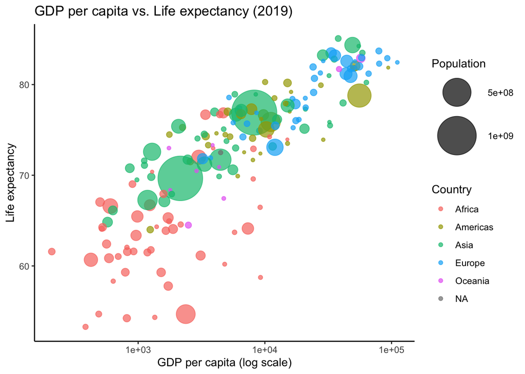

3.) Compare these two plots and comment what do you see. How has world developed through the last 60 years?

4.) Compute the average life expectancy for each continent in 1960 and 2019. Do the results fit with what do you see on the figures?

```
## # A tibble: 6 × 2
##   region   avg_lifeExp_1960
##   <chr>               <dbl>
## 1 Africa               41.5
## 2 Americas             58.6
## 3 Asia                 51.6
## 4 Europe               68.3
## 5 Oceania              56.4
## 6 <NA>                 70.7
```

```
## # A tibble: 6 × 2
##   region   avg_lifeExp_2019
##   <chr>               <dbl>
## 1 Africa               64.1
## 2 Americas             75.8
## 3 Asia                 74.6
## 4 Europe               79.4
## 5 Oceania              73.5
## 6 <NA>                 77.8
```

The average results we see in the scatterplots above, align with the results calculated by these average life expectancy by year tables.

5.) Compute the average LE growth from 1960-2019 across the continents. Show the results in the order of growth. Explain what do you see.

```
## # A tibble: 5 × 4
##   region   avg_le_1960 avg_le_2019 le_growth
##   <chr>          <dbl>       <dbl>     <dbl>
## 1 Asia            51.6        74.6     0.389
## 2 Africa          41.5        64.1     0.384
## 3 Americas        58.6        75.8     0.291
## 4 Oceania         56.4        73.5     0.290
## 5 Europe          68.3        79.4     0.188
```

6.) Show the histogram of GDP per capita for years of 1960 and 2019. Try to put both histograms on the same graph, see how well you can do it!

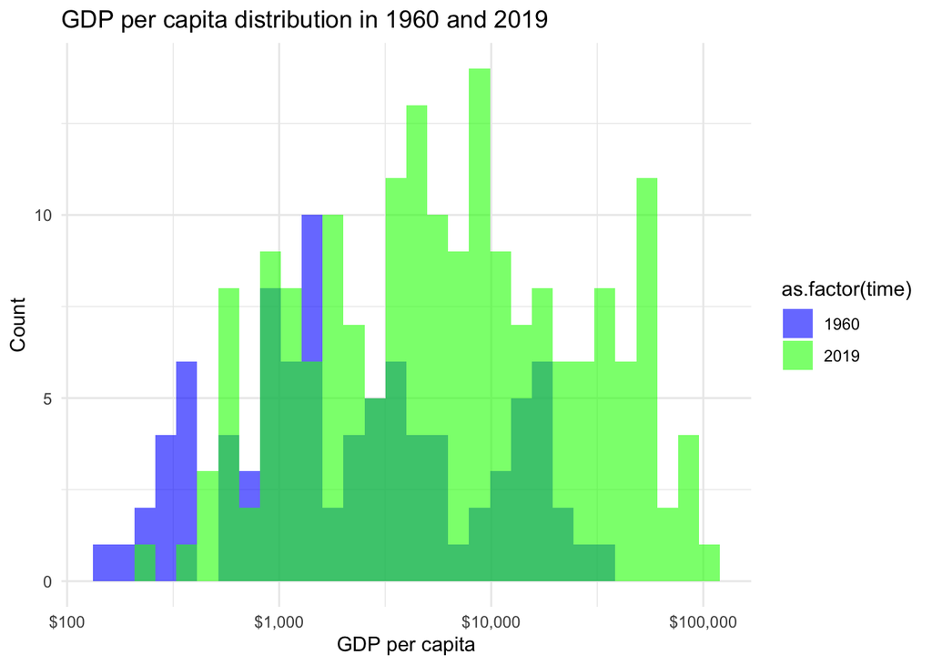

7.) What was the ranking of US in terms of life expectancy in 1960 and in 2019? (When counting from top.)

```
## # A tibble: 2 × 3
##    time  rank name
##   <dbl> <dbl> <chr>
## 1  1960    17 United States of America
## 2  2019    46 United States of America
```

8.) If you did this correctly, then you noticed that US ranking has been falling quite a bit. But we also have more countries in 2019–what about the relative rank divided by the corresponding number of countries that have LE data in the corresponding year?

```
## # A tibble: 2 × 3
##    time   rank name
##   <dbl>  <dbl> <chr>
## 1  1960 0.0904 United States of America
## 2  2019 0.235  United States of America
```

**Finally tell us how many hours did you spend on this PS.**

Personally, this problem set took up the whole week, as I spent about 2-3 hours a day working on it give or take. So in grand total I would say I worked around 12-15 hours total on this assignment.